# Cluster Report: All (5 datasets), 40 clusters

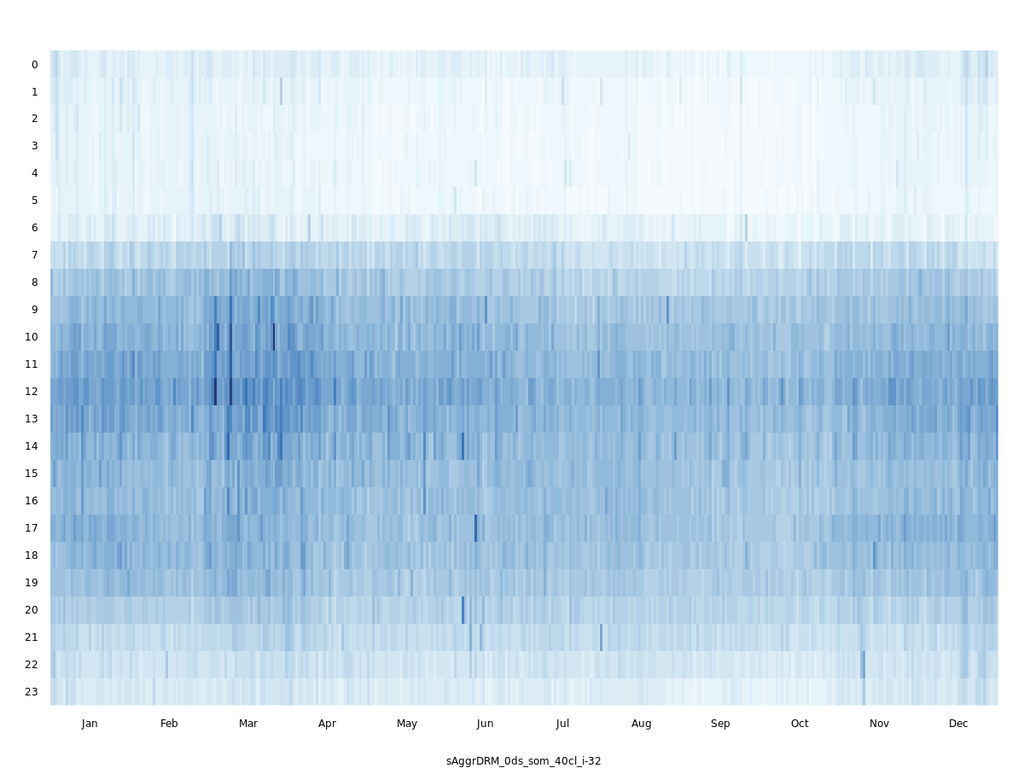

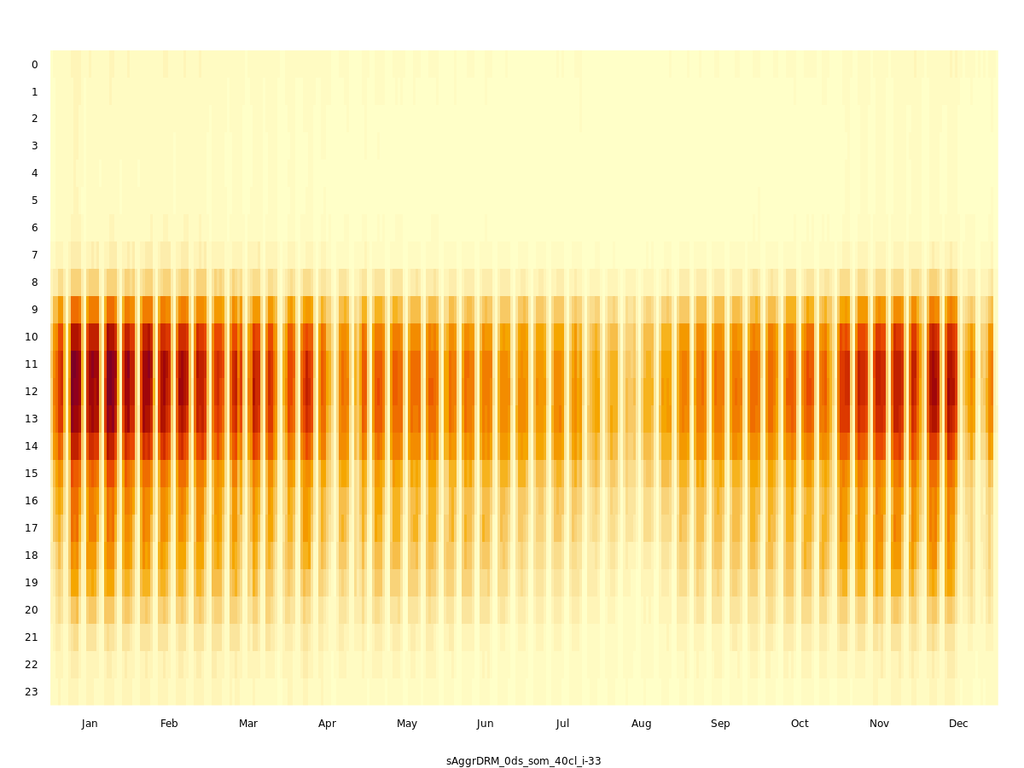

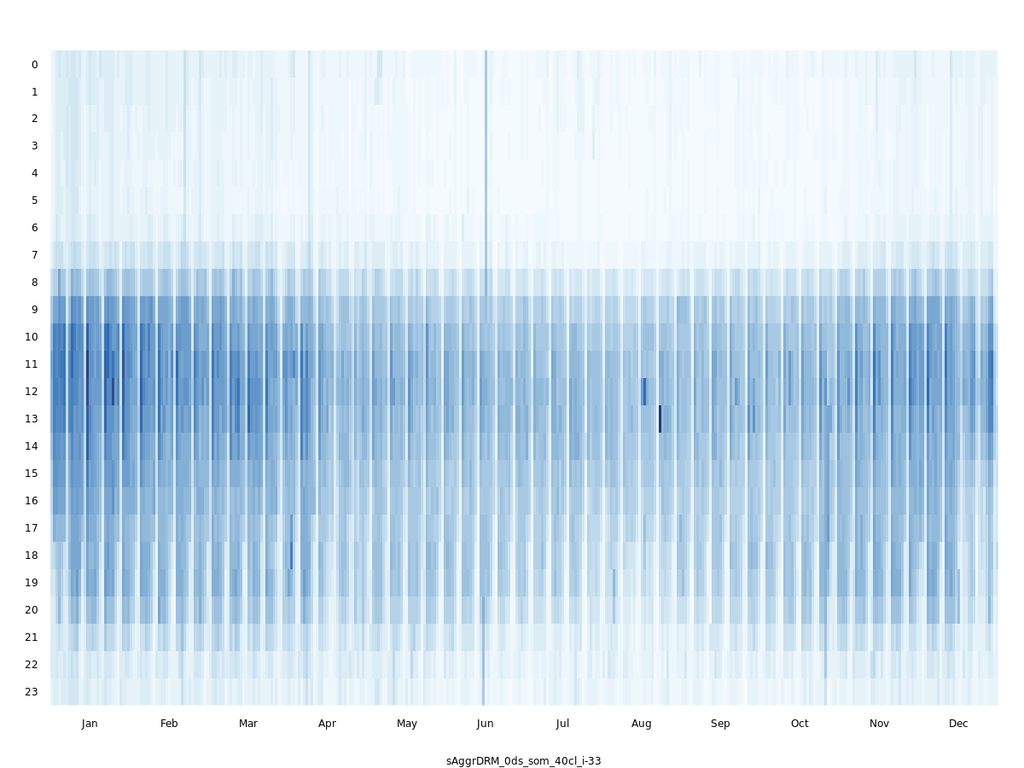

sAggrDRM > 5ds > som > μ > #31

101 TS (0.4%)

sAggrDRM > 5ds > som > σ > #31

101 TS (0.4%)

sAggrDRM > 5ds > som > μ > #32

981 TS (4.1%)

sAggrDRM > 5ds > som > σ > #32

981 TS (4.1%)

sAggrDRM > 5ds > som > μ > #33

387 TS (1.6%)

sAggrDRM > 5ds > som > σ > #33

387 TS (1.6%)

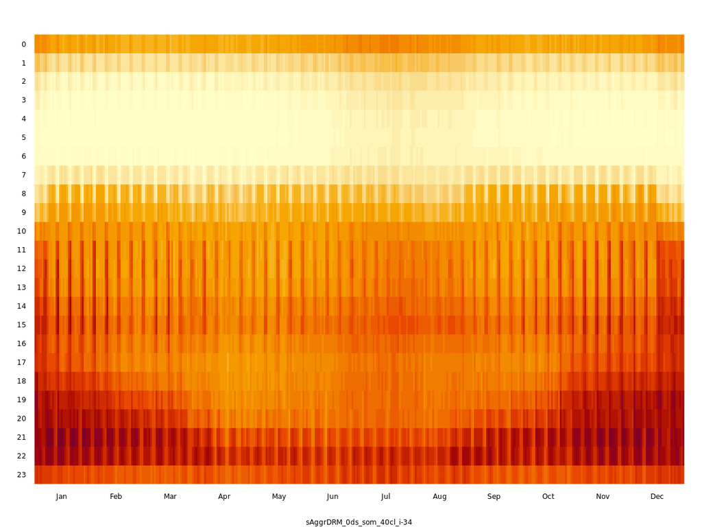

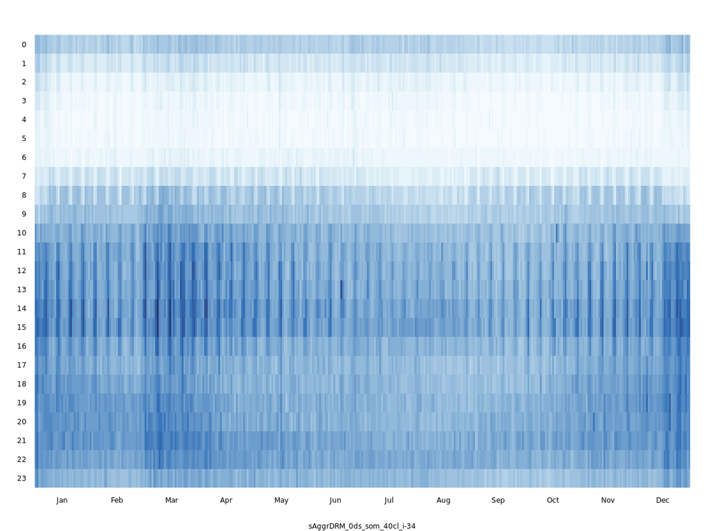

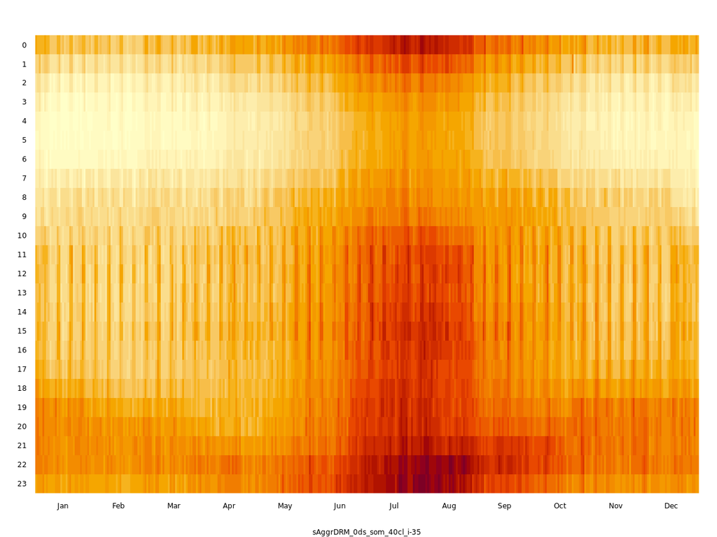

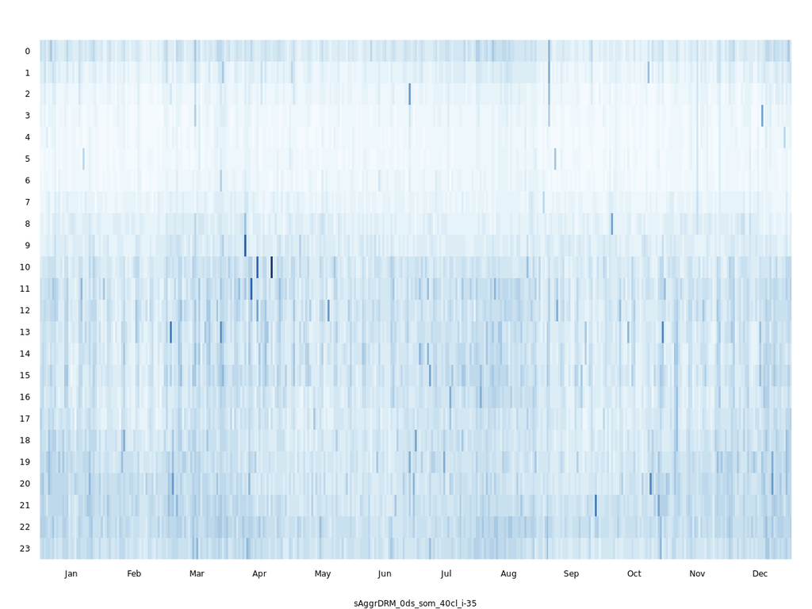

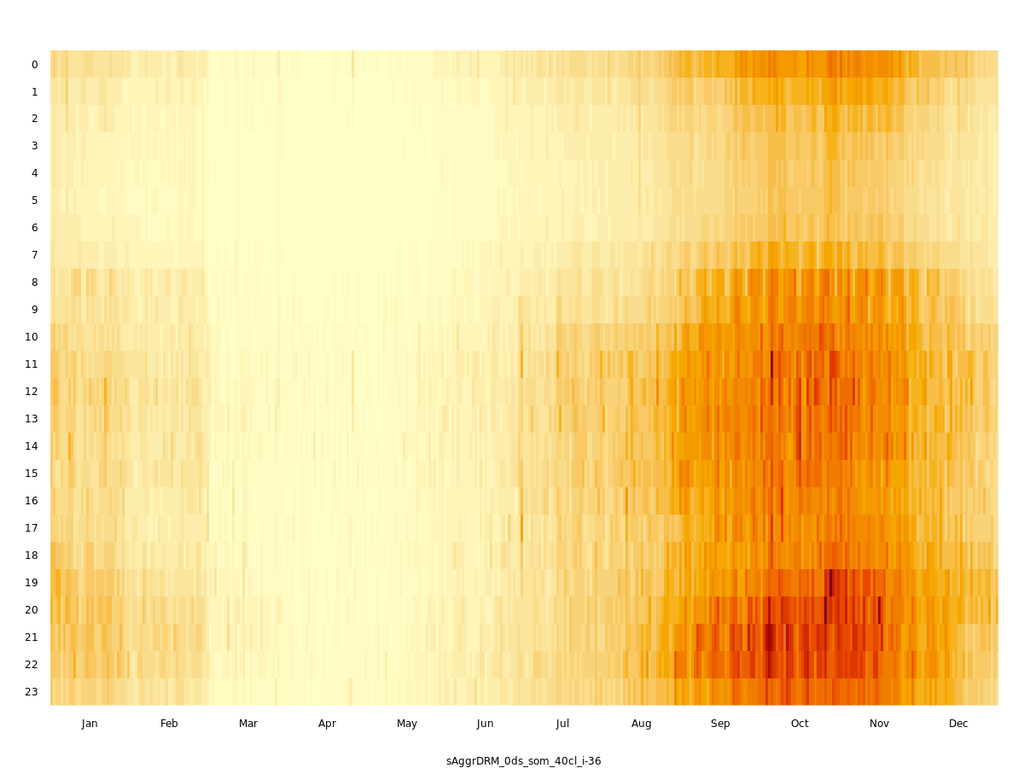

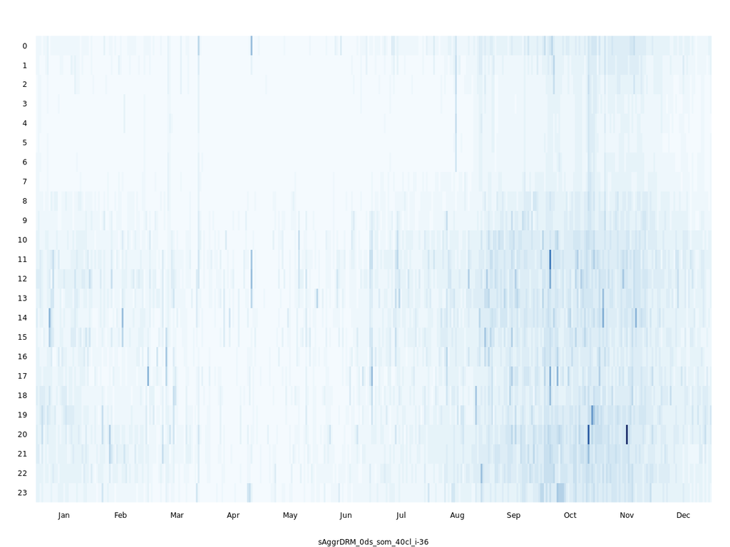

sAggrDRM > 5ds > som > μ > #34

1674 TS (7%)

sAggrDRM > 5ds > som > σ > #34

1674 TS (7%)

sAggrDRM > 5ds > som > μ > #35

1019 TS (4.3%)

sAggrDRM > 5ds > som > σ > #35

1019 TS (4.3%)

sAggrDRM > 5ds > som > μ > #36

143 TS (0.6%)

sAggrDRM > 5ds > som > σ > #36

143 TS (0.6%)

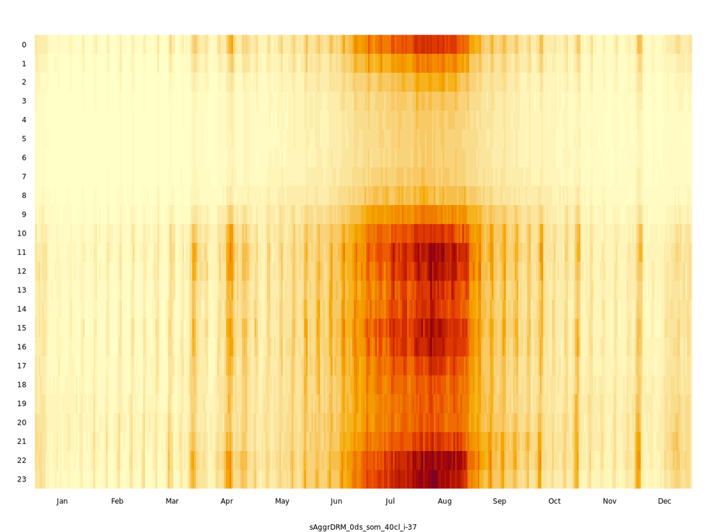

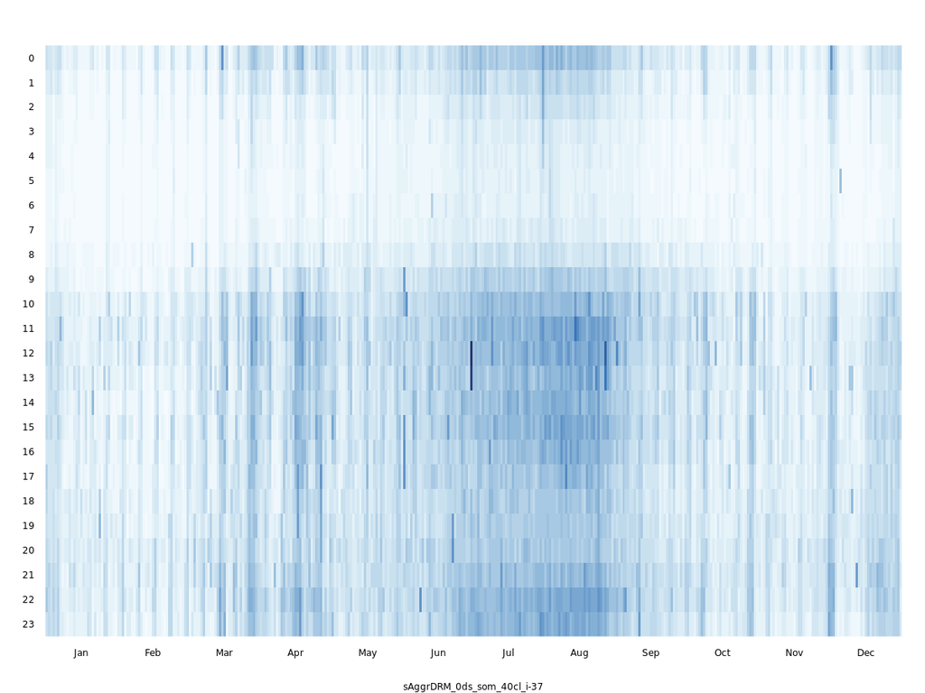

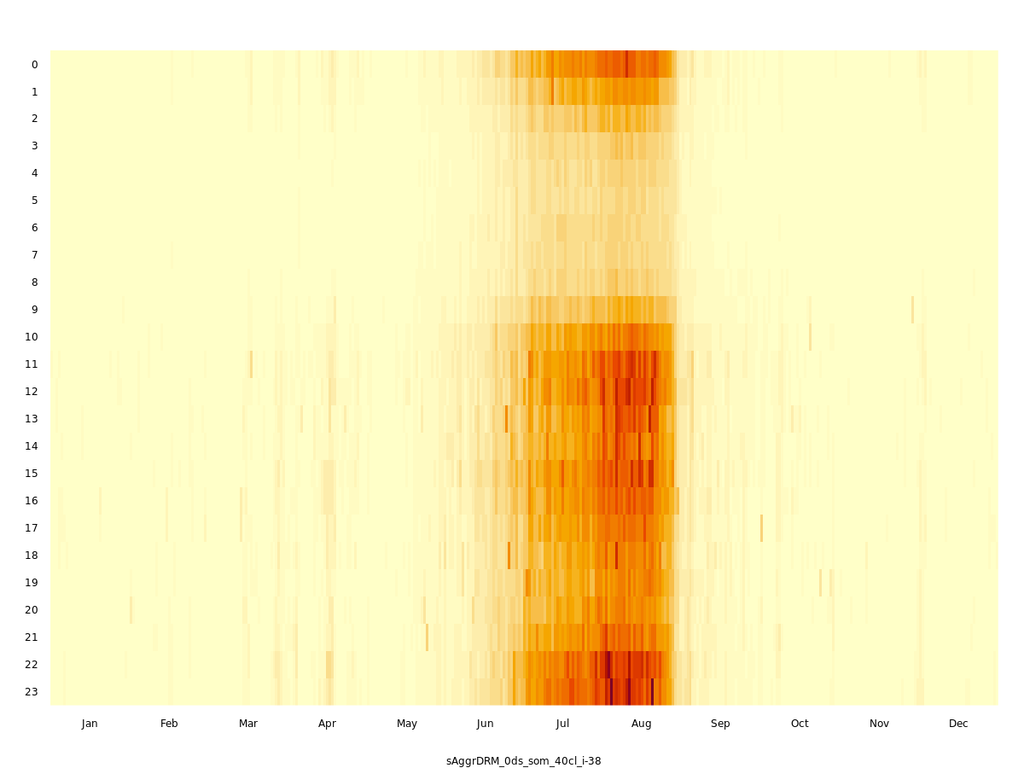

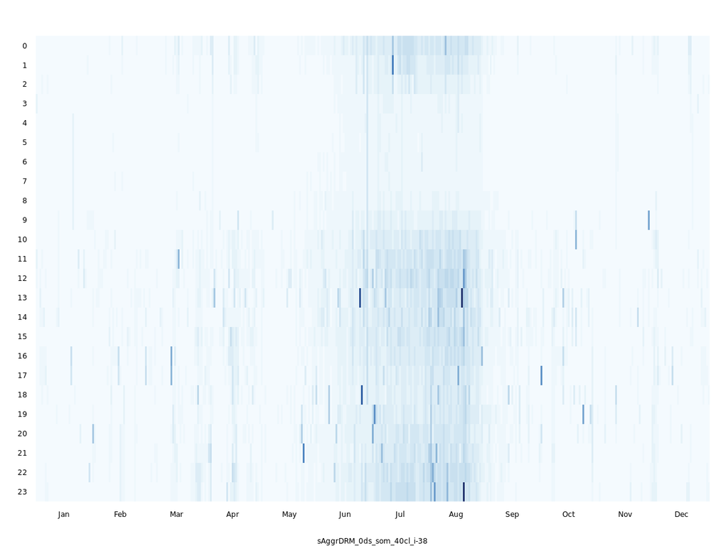

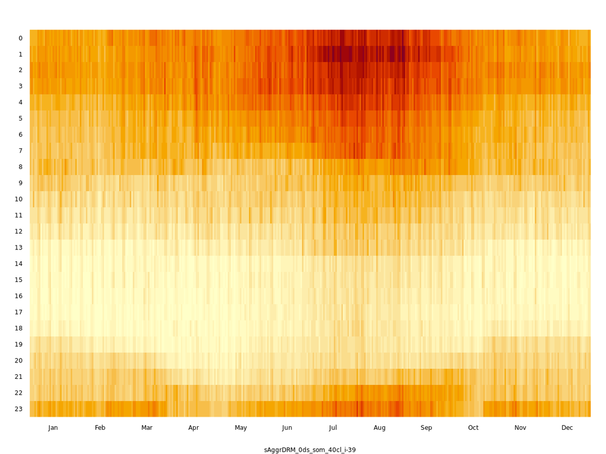

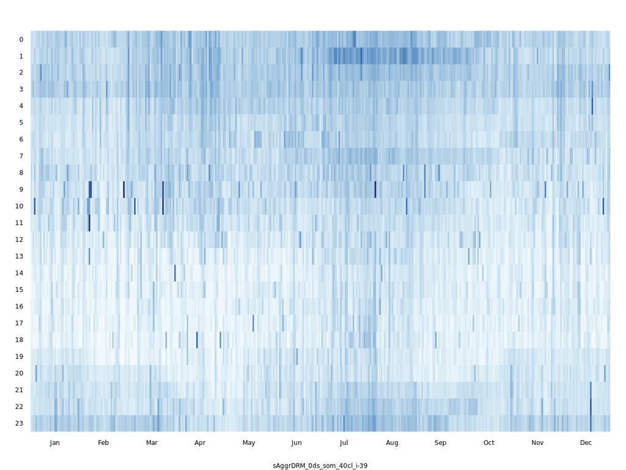

sAggrDRM > 5ds > som > μ > #37

363 TS (1.5%)

sAggrDRM > 5ds > som > σ > #37

363 TS (1.5%)

sAggrDRM > 5ds > som > μ > #38

98 TS (0.4%)

sAggrDRM > 5ds > som > σ > #38

98 TS (0.4%)

sAggrDRM > 5ds > som > μ > #39

70 TS (0.3%)

sAggrDRM > 5ds > som > σ > #39

70 TS (0.3%)

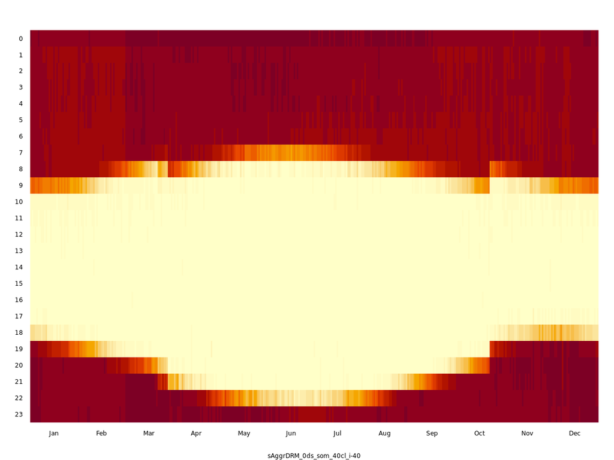

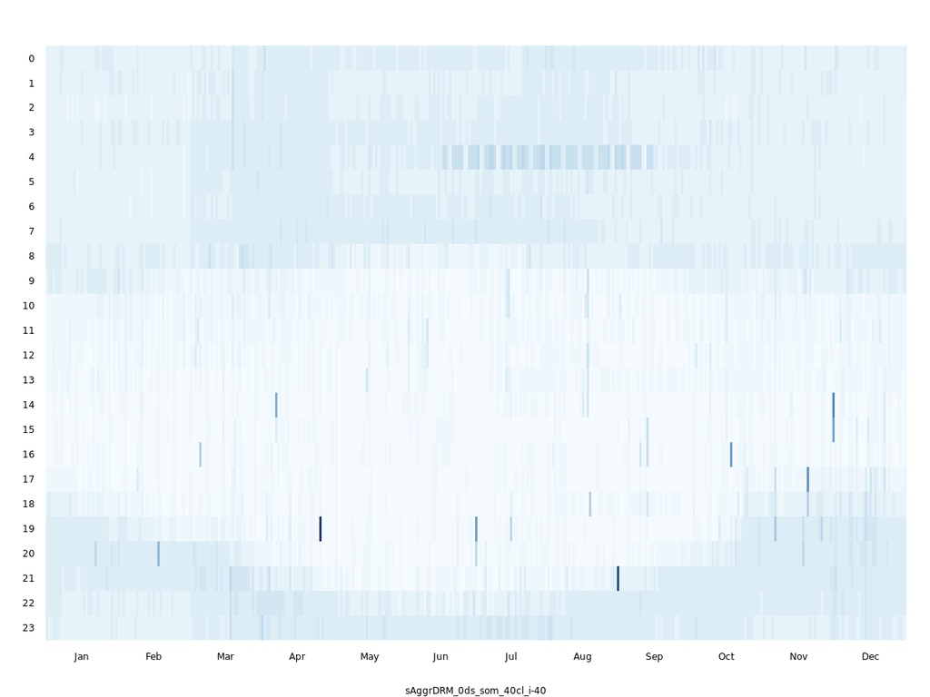

sAggrDRM > 5ds > som > μ > #40

233 TS (1%)

sAggrDRM > 5ds > som > σ > #40

233 TS (1%)